# Segunda parte-Laboratorio 1

Maria del Carmen Carranza Montero

9/10/2020

```r
suppressWarnings(library(starsdata))
suppressWarnings(library(tidyverse))
suppressWarnings(library(sf))
suppressWarnings(library(mapview))
suppressWarnings(library(stars))
suppressWarnings(library(RSQLite))
suppressWarnings(library(spacetime))
suppressWarnings(library(xts))
suppressWarnings(library(spDataLarge))
suppressWarnings(library(units))
suppressWarnings(library(cubelyr))
suppressWarnings(library(base))
suppressWarnings(library(spData))
suppressWarnings(library(spDataLarge))
suppressWarnings(library(rnaturalearthdata))
suppressWarnings(library(rnaturalearth))
suppressWarnings(library(rgeos))
suppressWarnings(library(tmap))
suppressWarnings(library(leaflet))
suppressWarnings(library(cartogram))
suppressWarnings(library(grid))
suppressWarnings(library(gganimate))
suppressWarnings(library(magick))
suppressWarnings(library(raster))
suppressWarnings(library(dplyr))
```

## **Ejercicios Parte 8.7 Libro de Lovelace**

#### Estos ejercicios se basan en un nuevo objeto, africa. Créelo usando los conjuntos de datos world y worldbank_df del paquete spData de la siguiente manera:

#### También vamos a utilizar los conjuntos de datos de spDataLarge zion y nlcd:

```r
africa <- world %>%
  filter(continent == "Africa", !is.na(iso_a2)) %>%
  left_join(worldbank_df, by = "iso_a2") %>%
  dplyr::select(name, subregion, gdpPercap, HDI, pop_growth) %>%
  st_transform("+proj=aea +lat_1=20 +lat_2=-23 +lat_0=0 +lon_0=25")
```

```r
zion <- st_read((system.file("vector/zion.gpkg", package = "spDataLarge")))
data(nlcd, package = "spDataLarge")
```

#### 1) Cree un mapa que muestre la distribución geográfica del Índice de Desarrollo Humano (HDI) en África con gráficos base (pista: use plot()) y paquetes tmap (pista: use tm_shape(africa) + …).

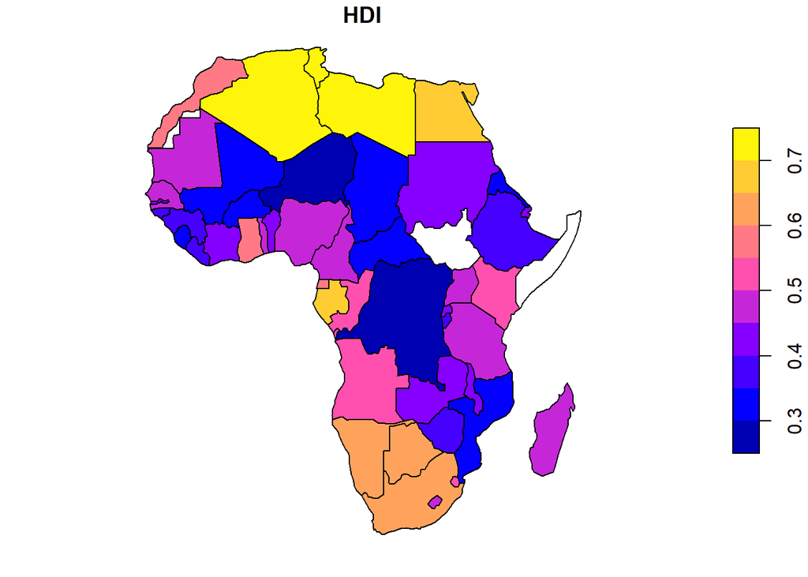

```r
plot(africa[4])
```

```r
afr1 <- cartogram_cont(africa, "HDI", itermax = 5)
```

```
## Mean size error for iteration 1: 6.03537025368672
```

```
## Mean size error for iteration 2: 3.64410634493783
```

```
## Mean size error for iteration 3: 2.45300713828664
```

```
## Mean size error for iteration 4: 1.85135460746932
```

```
## Mean size error for iteration 5: 1.53025529469271
```

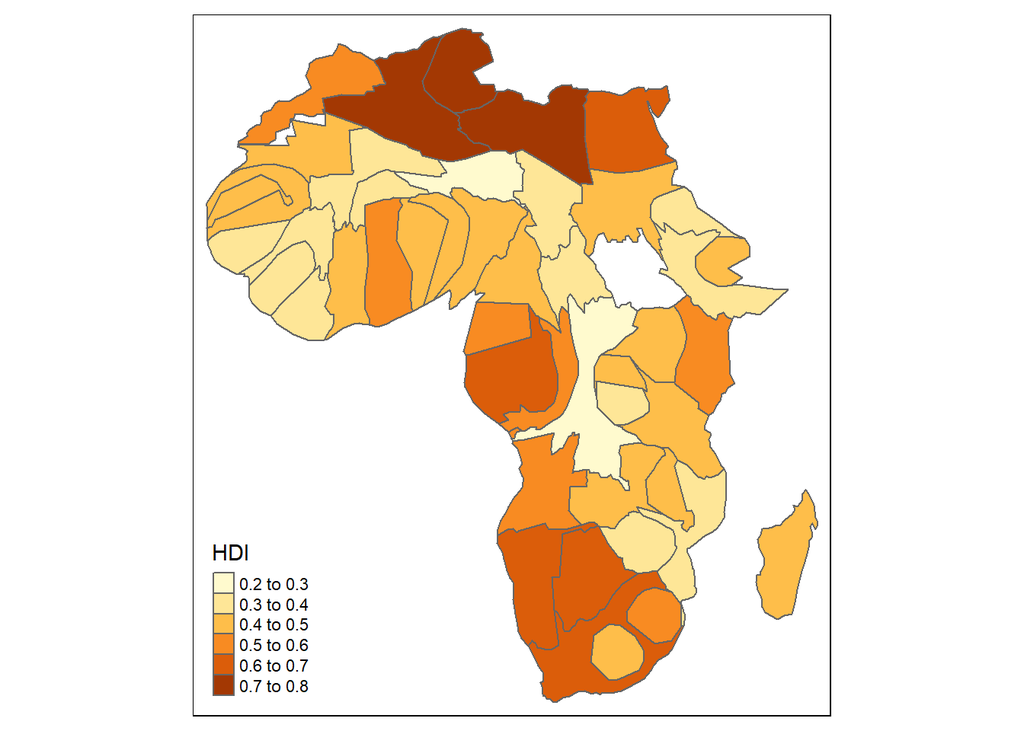

```r
tm_shape(afr1) + tm_polygons("HDI")
```

#### 1.1 Nombre dos ventajas de cada uno según la experiencia.

#### 1-Sencillos de aplicar

#### 2-Y ambos son fácil de interpretar

#### 1.2 Nombre otros tres paquetes de mapas y una ventaja de cada uno.

#### geogrid:Convierta polígonos geoespaciales en cuadrículas regulares o hexagonales

#### geofacet: Utilidades de facetado para datos geográficos

#### globe: Trazar vistas 2D y 3D de la Tierra, incluida la costa principal

#### 1.3 Bono: cree tres mapas más de África usando esos tres paquetes.

#### 2) Extienda el tmap creado para el ejercicio anterior para que la leyenda tenga tres bins: “Alto” (por HDI encima de 0,7), “Medio” (HDI entre 0,55 y 0,7) y “Bajo” (HDI por debajo de 0,55).

#### Bonificación: mejore la estética del mapa, por ejemplo, cambiando el título de la leyenda, las etiquetas de clase y la paleta de colores.

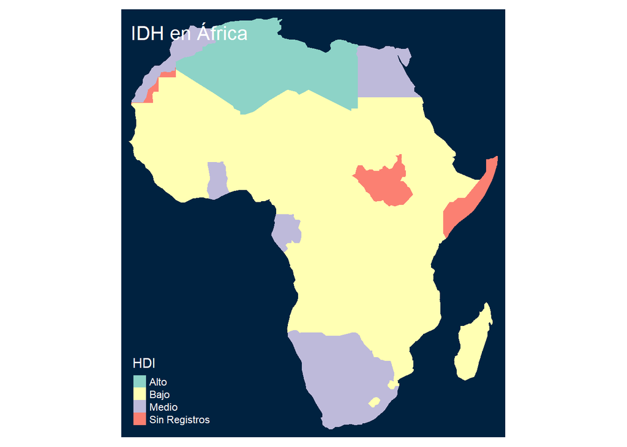

```r
africa <- africa %>%
  mutate(HDI =
           case_when(HDI < 0.55 ~ 'Bajo',
           HDI >= 0.55 & HDI < 0.7 ~ 'Medio',                            HDI > 0.7 ~'Alto',                                            TRUE ~ 'Sin Registros'))

(afr2 <- tm_shape(africa) + tm_fill(col = "HDI") + tm_style("cobalt") + tm_layout(title = "IDH en África") + tm_layout(scale = 1))
```

#### 3) Represente las subregiones de Africa en el mapa. Cambie la paleta de colores predeterminada y el título de la leyenda. A continuación, combine este mapa y el mapa creado en el ejercicio anterior en un solo gráfico.

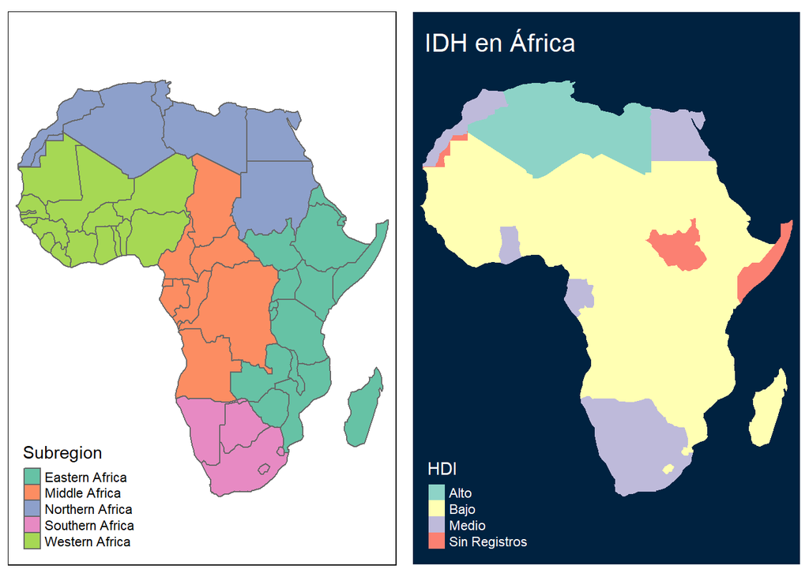

```r
afr3 <- tm_shape(africa) + tm_polygons(col = "subregion",
              title = "Subregion",
              palette = "Set2")
tmap_arrange(afr3, afr2)
```

#### 4) Cree un mapa de cobertura terrestre del Parque Nacional Zion.

#### 4.1 Cambie los colores predeterminados para que coincidan con su percepción de las categorías de cobertura terrestre

### 4.2 Agregue una barra de escala y una flecha norte y cambie la posición de ambas para mejorar el atractivo estético del mapa

```r
lc_colors <-  c("#476ba0", "#aa0000", "#b2ada3", "#68aa63", "#a58c30", "#c9c977", "#dbd83d", "#bad8ea")

cob_zion <- tm_shape(nlcd) + tm_raster(style = "cont", palette = lc_colors, title = "Mapa de Cobertura terrestre") +
  tm_shape(zion) + tm_borders(lwd = 3) +
  tm_layout(legend.frame = TRUE, legend.position = c(0.6, "top")) +
  tm_scale_bar(text.size = 1, position = "left") +
  tm_compass(type = "8star", position = c("left", "bottom"))
  tm_layout(frame.lwd = 4)
```

[output not shown]

```r
cob_zion
```

```
## stars object downsampled to 888 by 1125 cells. See tm_shape manual (argument raster.downsample)
```

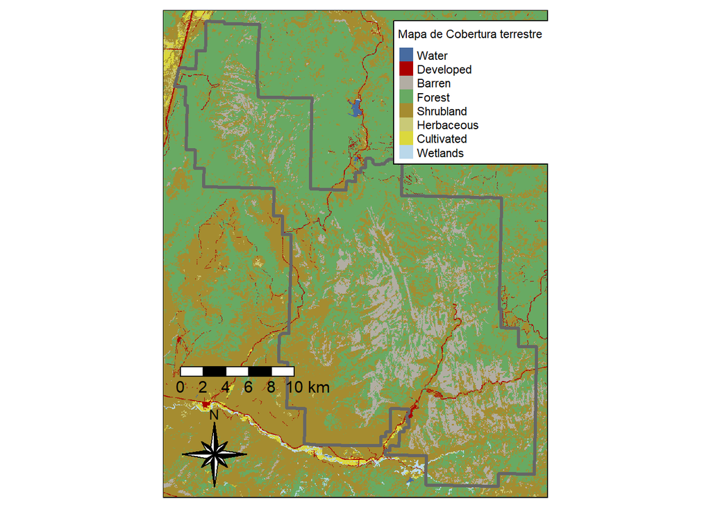

### 4.3 Bonificación: agregue un mapa insertado de la ubicación del Parque Nacional Zion en el contexto del estado de Utah. (Sugerencia: un objeto que representa a Utah puede ser un subconjunto del conjunto de datos us_states).

```r
utah <- dplyr::filter(us_states, NAME == "Utah")
zion_bbox <- st_as_sfc(st_bbox(nlcd))

map_ins <- tm_shape(utah) +
  tm_polygons(lwd = 3, border.col = "black") +
  tm_shape(zion_bbox) +
  tm_polygons(col = "green", lwd = 1) +
  tm_layout(title = "UTAH", title.size = 0.6, title.position =    c("center", "center")) +
  tm_layout(frame = FALSE, bg.color = NA)

print(cob_zion, vp = grid::viewport(0.5, 0.5, width = 0.95, height = 0.95))
```

```
## stars object downsampled to 888 by 1125 cells. See tm_shape manual (argument raster.downsample)
```

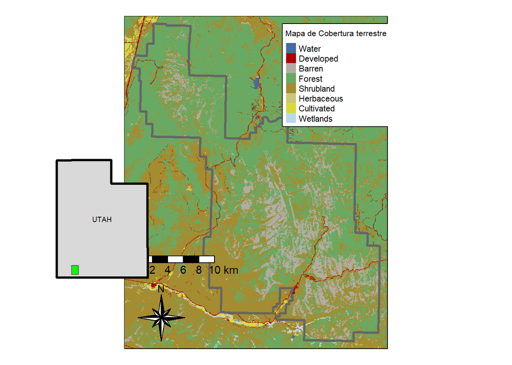

```r
print(map_ins, vp = grid::viewport(0.2, 0.4, width = 0.35, height = 0.35))
```

#### 5) Cree mapas de facetas de países de África oriental:

### 5.1 Con una faceta que muestra el IDH y la otra que representa el crecimiento de la población (pista: usando variables HDI y pop_growth, respectivamente)

### 5.2 Con un ‘múltiplo pequeño’ por país

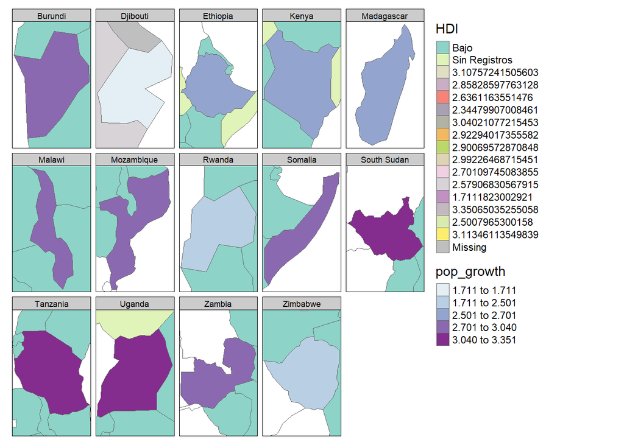

```r
east_afr <- africa %>%
  filter(subregion %in% "Eastern Africa")

tm_shape(east_afr) +
  tm_polygons(col = c("HDI", "pop_growth")) +
  qtm(africa, fill = NULL) +
  tm_shape(east_afr) +
  tm_polygons("pop_growth", style = "jenks",
              palette = "BuPu") +
  tm_facets(by = "name", drop.NA.facets = TRUE)
```

#### 6) Sobre la base de los ejemplos de mapas de facetas anteriores, cree mapas animados de África Oriental:

### 6.1 Mostrando primero la distribución espacial de las puntuaciones del IDH y luego el crecimiento de la población

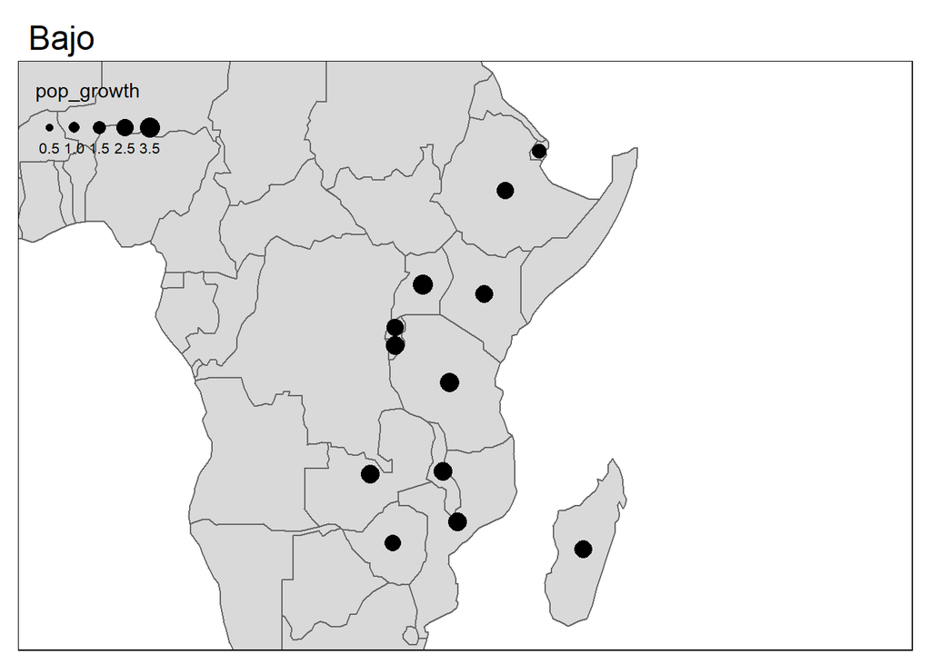

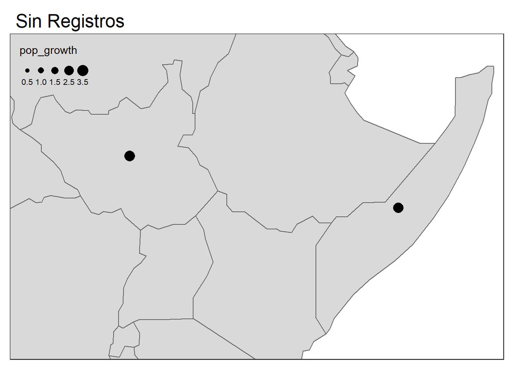

```r
graf_anim <- tm_shape(africa) + tm_polygons() +
   tm_shape(east_afr) + tm_dots(size = "pop_growth") +
   tm_facets(along = "HDI", free.coords = TRUE)
graf_anim
```

```r
#tmap_animation(graf_anim, delay = 25)
```

```r
#m <- tm_shape(east_afr) +
 # tm_polygons(col = c("HDI", "pop_growth")) +
 # qtm(africa, fill = NULL) +
 # tm_facets(ncol = 1, nrow = 1)
  #tmap_animation(m, filename = "m.gif")
 # browseURL("m.gif")

#m <- tm_shape(east_afr) +
 # tm_polygons("pop_growth",
              #style = "jenks", palette = "BuPu") +
 # tm_facets(by = "name", drop.NA.facets = TRUE, ncol = 1, nrow = 1)

#tmap_animation(m, filename = "m.gif", width = 1500, height = 1500)
#browseURL("m.gif")
```